# TRAVIS: Uma análise comparativa das linguagens Java e Ruby

EQUIPE: JÚLIA CAMPOS julia.campos31@gmail.com, FABIO SALES fosales@gmail.com, IGOR ASSIS guinho.assis@gmail.com, FRANKLIN CASTRO franklinrene_castro@hotmail.com

06 de Agosto de 2017

## Introdução

Os casos de teste são um conjunto de condições utilizadas na engenharia de software para garantir que o software funcione de acordo com os requisitos funcionais e não funcionais estabelecidos anteriormente, dessa forma, aumentando a produtividade e evitando o retrabalho da equipe de desenvolvimento. A produtividade de uma linguagem de programação pode ser medida de várias formas, como por exemplo: a partir da quantidade de erros ao longo do trabalho, da curva de aprendizagem da linguagem utilizada, da quantidade de linhas de código, dos casos de teste, etc.

A motivação para este trabalho é analisar a produtividade da linguagem de programação Java quando comparada com a linguagem de programação Ruby, levando em consideração a quantidade de linhas de código escritas e a quantidade de pessoas na equipe, além de analisar se a construção de caso de teste propicia uma maior taxa de sucesso na execução de jobs, consequentemente, menor é o tempo gasto com retrabalho.  
Para desenvolver a análise foram elaboradas as seguintes questões de pesquisa:

**R1: Levando em consideração a quantidade de linhas de código escritas e a média do tamanho da equipe, é correto afirmar que a linguagem de programação Java é mais produtiva do que a linguagem de programação Ruby?**

**R2: Considerando a média de falha nos casos de teste é correto afirmar que a linguagem de programação Java possui menos erros do que a linguagem de programação Ruby?**

**R3: Os jobs que possuem casos de teste são menos suscetíveis à falhas do que os que não possuem?**

**R4: Os jobs que possuem casos de teste, se escritos em java, falham menos do que os jobs que possuem casos de teste escritos em Ruby?**

**R5: Levando em consideração a média da quantidade de casos de teste, é correto afirmar que a quantidade de casos de teste influência na quantidade de sucesso dos jobs?**

## Metodologia

Para a elaboração do trabalho foi realizada uma pesquisa empírica na qual foram analisados **2.640.006** registros colhidos da base de dados “travis-sample”, resumo da base de dados do Travis Torrent, que foi disponibilizada na página do professor Rodrigo Rocha. Para coletar os dados importantes para cada questão de pesquisa foi utilizada a biblioteca “dply” do R, que permite utilizar as funções group by, filter, etc., permitindo diferentes manipulações nas tabelas da base de dados. Na fase de transformação dos dados, foram realizados diferentes agrupamentos, de acordo com as propriedades de cada questão, além da retirada de valores “NA” de algumas tabelas, permitindo, desta forma, a execução de alguns cálculos. Outra transformação foi a retirada dos outliers no momento de elaborar o gráfico da questão R1, uma vez que existiam valores muito discrepantes em relação às medições geradas no gráfico.

Após o agrupamento e a análise dos dados foram gerados gráficos do tipo boxplot e barras, nos quais podem ser visualizados os resultados gerados. Depois da plotagem dos gráficos foi realizada a validação dos dados a partir do teste de Wilcoxon, no qual é verificada a veracidade de hipóteses não paramétricas. Neste teste a veracidade da hipótese é calculada a partir do valor de “P”, e **caso p-value < 0.5 a hipótese nula é considerada falsa**, logo a hipótese descrita pelo pesquisador é verdadeira.

## Carrega os dados

```r
travis <- readRDS("travis-sample.rds")
```

## Resultados

**R1. Levando em consideração a quantidade de linhas de código escritas e a média do tamanho da equipe, é correto afirmar que a linguagem de programação Java é mais produtiva do que a linguagem de programação Ruby?**

Após agrupamento, sumarização dos dados e a validação da hipótese, os resultados gerados foram plotados em um gráfico do tipo Boxplot, no qual os valores são divididos em quartis, estando o menor valor representado na barra inferior, a mediana representada por uma barra acima do segundo quartil, e o maior valor representado através da barra superior

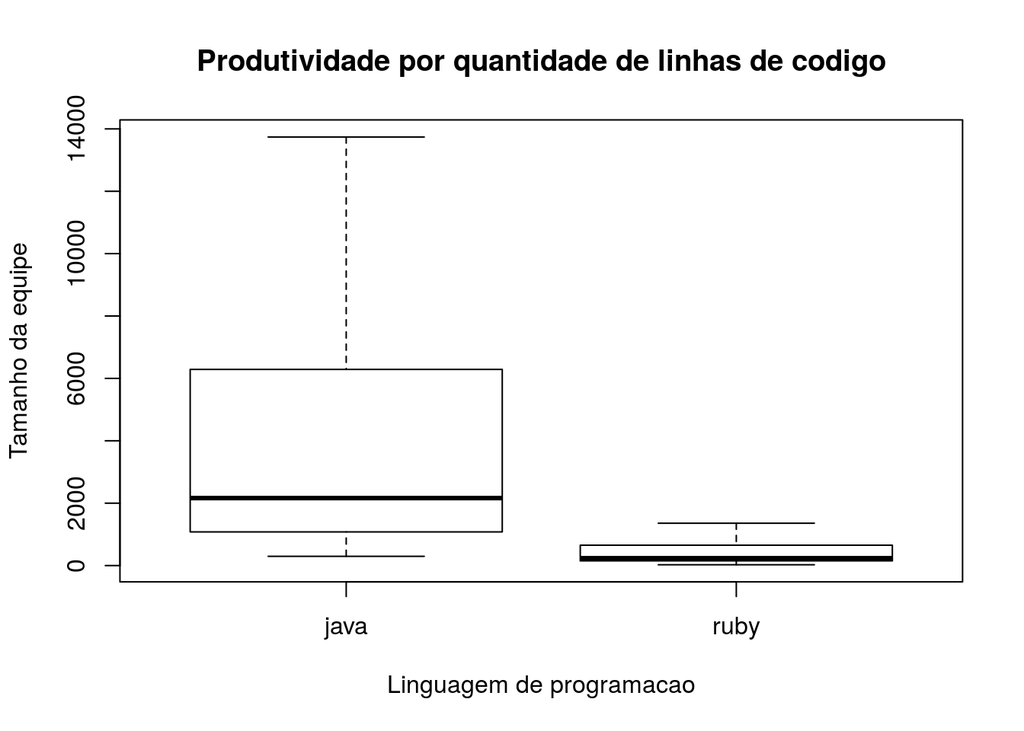

```r
travis <- readRDS("travis-sample.rds")
njobs_r1 <- travis  %>%
group_by(gh_project_name, gh_lang)  %>%
summarise(max_build_id = max(tr_build_id, digits = 0), mean_team_size = mean(gh_team_size), mean_gh_sloc = mean(gh_sloc), mean_pessoa_linha_codigo = mean_gh_sloc/mean_team_size)

boxplot(njobs_r1$mean_pessoa_linha_codigo ~ njobs_r1$gh_lang, outline = F, main="Produtividade por quantidade de linhas de codigo", xlab="Linguagem de programacao", ylab="Tamanho da equipe")
```

```r
wilcox.test(njobs_r1$mean_team_size, njobs_r1$mean_gh_sloc, paired = T, conf.level = 0.95)
```

```
##
##  Wilcoxon signed rank test with continuity correction
##
## data:  njobs_r1$mean_team_size and njobs_r1$mean_gh_sloc
## V = 0, p-value = 1.671e-11
## alternative hypothesis: true location shift is not equal to 0
```

**R2: Considerando a média de falha nos casos de teste é correto afirmar que a linguagem de programação Java possui menos erros do que a linguagem de programação Ruby?**

Para realizar esta análise foram estudadas as seguintes colunas: gh_lang, que possui o nome da linguagem de programação e tr_log_num_tests_failed, que possui a quantidade de testes que falharam. Como haviam algumas células na tabela sem valores, foi necessário a utilização da função **na.rm=TRUE**, para remover os valores NA da tabela.

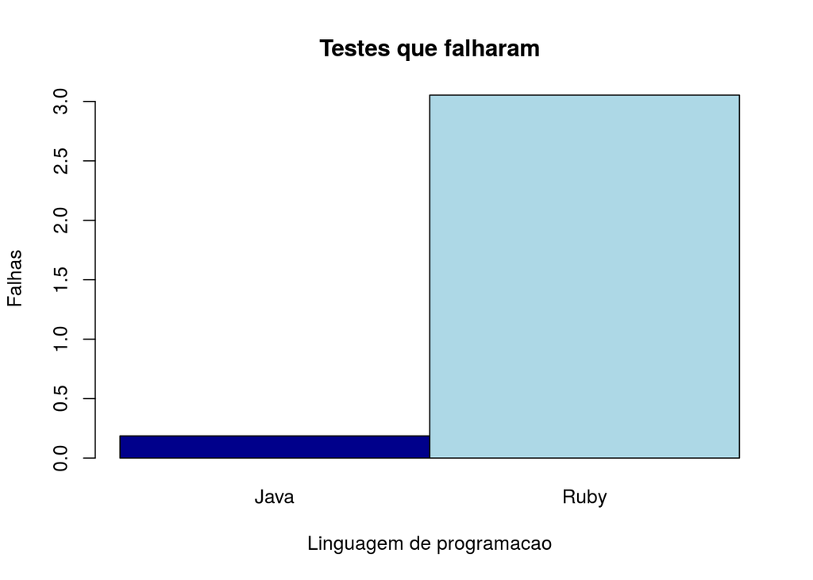

```r
njobs_r2 <- travis %>%   group_by(gh_lang) %>% summarise(mean_tr_log_num_tests_failed = mean(tr_log_num_tests_failed, na.rm=TRUE))

barplot(njobs_r2$mean_tr_log_num_tests_failed, space = F, names=c("Java","Ruby"), col= c("dark blue","light blue"), main = "Testes que falharam", ylab = "Falhas", xlab = "Linguagem de programacao")
```

```r
wilcox.test(njobs_r2$mean_tr_log_num_tests_failed, conf.level = 0.95)
```

```
##
##  Wilcoxon signed rank test
##
## data:  njobs_r2$mean_tr_log_num_tests_failed
## V = 3, p-value = 0.5
## alternative hypothesis: true location is not equal to 0
```

**R3: Os jobs que possuem casos de teste são menos suscetíveis à falhas do que os que não possuem?**

Para responder esta pergunta foram usadas as seguintes colunas: build_successful, que apresenta os valores “true” quando a build foi compilada com sucesso e “false” caso contrário, tr_log_bool_tests_ran que apresenta o valor “true” quando houve caso de teste e “false” quando não houve casos de teste e num_jobs, que representa o número de jobs executados.

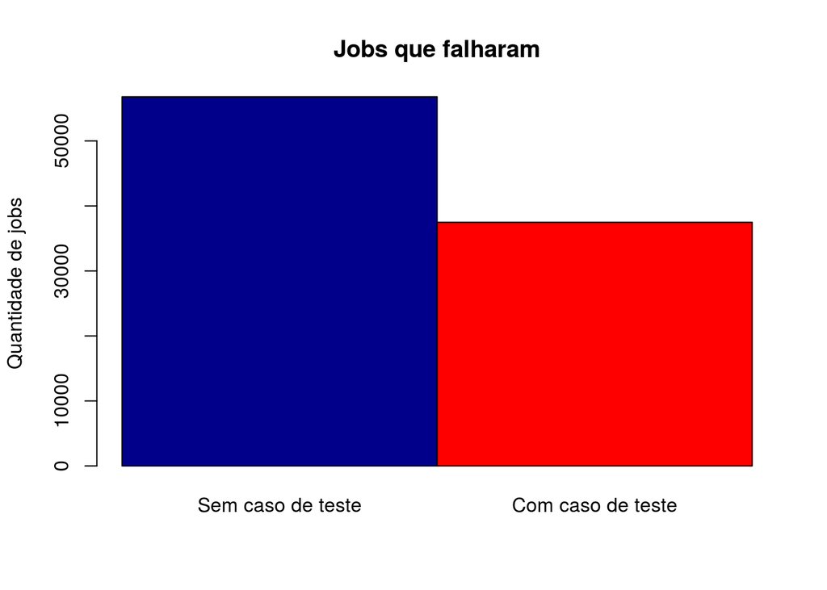

```r
njobs_r3 <- travis %>%
filter(build_successful == 'FALSE') %>%
group_by(tr_log_bool_tests_ran, build_successful) %>% summarise(num_jobs = n())

barplot(njobs_r3$num_jobs, space = F, names=c("Sem caso de teste","Com caso de teste"), col= c("dark blue","red"), main = "Jobs que falharam", ylab = "Quantidade de jobs")
```

```r
wilcox.test(njobs_r3$num_jobs, conf.level = 0.95)
```

```
##
##  Wilcoxon signed rank test
##
## data:  njobs_r3$num_jobs
## V = 3, p-value = 0.5
## alternative hypothesis: true location is not equal to 0
```

V = 3, p-value = 0.5

**R4: Os jobs que possuem casos de teste, se escritos em java, falham menos do que os jobs que possuem casos de teste escritos em Ruby?**

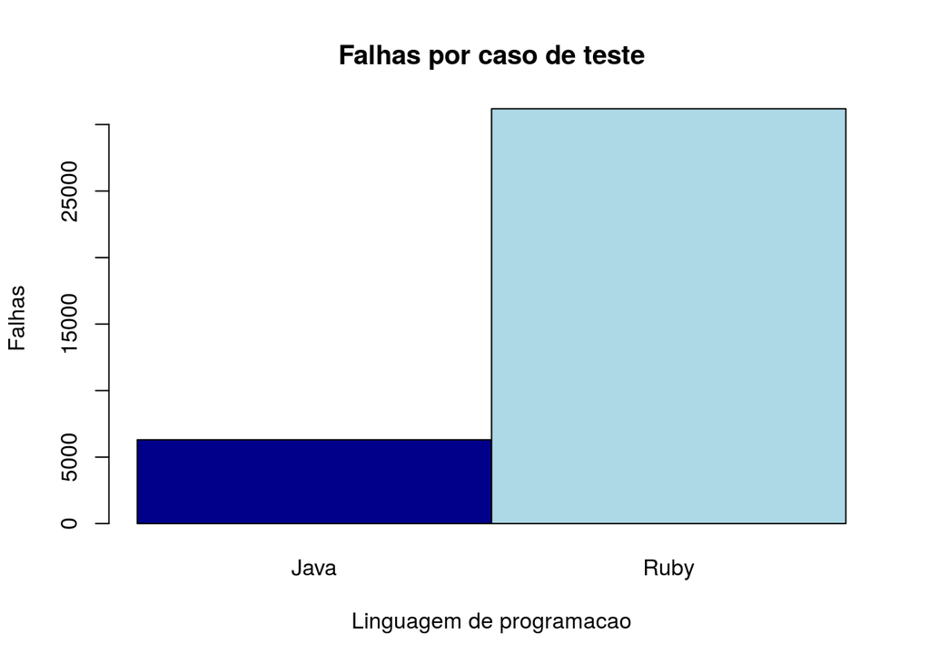

```r
njobs_r4 <- travis %>% filter(tr_log_bool_tests_ran == 'TRUE', build_successful == 'FALSE') %>%    group_by(tr_log_bool_tests_ran, gh_lang ,build_successful) %>% summarise(num_jobs = n())

barplot(njobs_r4$num_jobs, space = F, names=c("Java","Ruby"), col= c("dark blue","light blue"), main = "Falhas por caso de teste", ylab = "Falhas", xlab = "Linguagem de programacao")
```

```r
wilcox.test(njobs_r4$num_jobs, conf.level = 0.95 )
```

```
##
##  Wilcoxon signed rank test
##
## data:  njobs_r4$num_jobs
## V = 3, p-value = 0.5
## alternative hypothesis: true location is not equal to 0
```

**R5: Levando em consideração a média da quantidade de casos de teste, é correto afirmar que a quantidade de casos de teste influência na quantidade de sucesso dos jobs?**

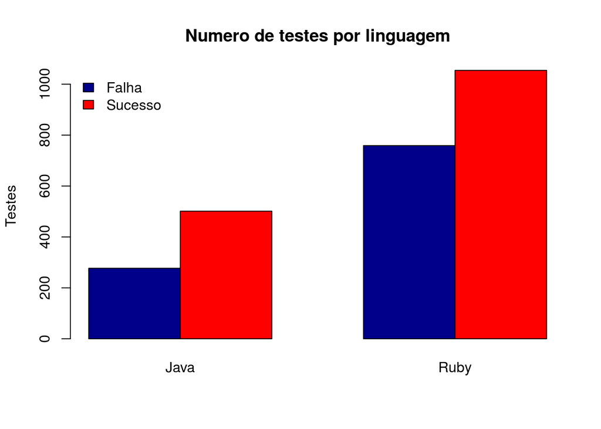

```r
njobs_r5 <- travis %>% group_by(gh_lang, build_successful) %>% summarise(mean_num_test = mean(tr_log_num_tests_ok, na.rm=TRUE))

z <- matrix(c(njobs_r5$mean_num_test[1], njobs_r5$mean_num_test[2], njobs_r5$mean_num_test[3], njobs_r5$mean_num_test[4]), 2, 2)
colnames(z) <- c("Java","Ruby")
barplot(z, beside=TRUE, main = "Numero de testes por linguagem", col=c("dark blue", "red"), ylab = "Testes")
legend("topleft", legend=c("Falha", "Sucesso"), fill=c("dark blue", "red"), bty="n")
```

```r
wilcox.test(njobs_r5$mean_num_test, conf.level = 0.95)
```

```
##
##  Wilcoxon signed rank test
##
## data:  njobs_r5$mean_num_test
## V = 10, p-value = 0.125
## alternative hypothesis: true location is not equal to 0
```

## Conclusão

Entre as dificuldades encontradas podemos citar: Achar o melhor tipo de teste de validação para realizar as modificações necessárias no momento da plotagem de alguns gráficos, tais como o de barras duplas e o boxplot. Como trabalhos futuros podemos citar o uso de amostras maiores para realizar os testes. Pode-se utilizar outros datasets contendo metadados de jobs de outras linguagens de programação e de outros projetos.